# Homework 2 Kevin Russell

# Problem 1

For our first problem, we will use data obtained from past Eurovision song contests. The data can be found as contestants.Rda and votes.Rda on HuskyCT.

## Part A

Part A of the problem will concern the data available in contestants.Rda.

```r
library(dplyr)
library(tidyverse)
```

```r
library(ggplot2)
```

### Question (i). 8 points.

Load the “contestants” data frame into R.

```r
load("C:/Users/kruss/Downloads/contestants.Rda")

contestants |>
  glimpse()
```

```
## Rows: 1,734
## Columns: 21
## $ year              <dbl> 1956, 1956, 1956, 1956, 1956, 1956, 1956, 1956, 1956…
## $ to_country_id     <chr> "ch", "nl", "be", "de", "fr", "lu", "it", "nl", "be"…
## $ to_country        <chr> "Switzerland", "Netherlands", "Belgium", "Germany", …
## $ performer         <chr> "Lys Assia", "Jetty Paerl", "Fud Leclerc", "Walter A…
## $ song              <chr> "Refrain", "De Vogels Van Holland", "Messieurs Les N…
## $ place_contest     <dbl> 2, 2, 2, 2, 2, 2, 2, 2, 2, 2, 2, 2, 1, 2, 3, 4, 4, 6…
## $ sf_num            <dbl> NA, NA, NA, NA, NA, NA, NA, NA, NA, NA, NA, NA, NA, …
## $ running_final     <dbl> 2, 1, 3, 4, 5, 13, 7, 8, 10, 11, 12, 14, 6, 8, 9, 2,…
## $ running_sf        <dbl> NA, NA, NA, NA, NA, NA, NA, NA, NA, NA, NA, NA, NA, …
## $ place_final       <dbl> 2, 2, 2, 2, 2, 2, 2, 2, 2, 2, 2, 2, 1, 2, 3, 4, 4, 6…
## $ points_final      <dbl> NA, NA, NA, NA, NA, NA, NA, NA, NA, NA, NA, NA, 31, …
## $ place_sf          <dbl> NA, NA, NA, NA, NA, NA, NA, NA, NA, NA, NA, NA, NA, …
## $ points_sf         <dbl> NA, NA, NA, NA, NA, NA, NA, NA, NA, NA, NA, NA, NA, …
## $ points_tele_final <dbl> NA, NA, NA, NA, NA, NA, NA, NA, NA, NA, NA, NA, NA, …
## $ points_jury_final <dbl> NA, NA, NA, NA, NA, NA, NA, NA, NA, NA, NA, NA, NA, …
## $ points_tele_sf    <dbl> NA, NA, NA, NA, NA, NA, NA, NA, NA, NA, NA, NA, NA, …
## $ points_jury_sf    <dbl> NA, NA, NA, NA, NA, NA, NA, NA, NA, NA, NA, NA, NA, …
## $ composers         <chr> "Georg Benz Stahl", "Cor Lemaire", "Jacques Say;Jean…
## $ lyricists         <chr> NA, "Annie M. G. Schmidt", "Robert Montal", NA, "Rac…
## $ lyrics            <chr> "(Refrain d'amour...)\\n\\nRefrain, couleur du ciel,…
## $ youtube_url       <chr> "https://youtube.com/watch?v=IyqIPvOkiRk", "https://…
```

Using this data frame as a starting point, apply dplyr verbs to create another data frame which meets the following criteria:

- include exactly two columns: one named performer, and another named nperformances. The cells of performer should give the names of performers. The cells in nperformances should tell us the number of times a performer appeared in the dataset.
- Do not include any performers with fewer than three Eurovision performances.
- Sort the rows such that they are in descending order based on the number of performances. For example, anyone with four performances should appear above anyone with three performances.

```r
three_perfs <- contestants |>
  group_by(performer) |>
  summarize(nperformances = n()) |>
    filter(nperformances >= 3) |>
    arrange(desc(nperformances))

three_perfs
```

```
## # A tibble: 14 × 2
##    performer           nperformances
##    <chr>                       <int>
##  1 Fud Leclerc                     4
##  2 Chiara                          3
##  3 Corry Brokken                   3
##  4 Domenico Modugno                3
##  5 Evridiki                        3
##  6 Katja Ebstein                   3
##  7 Kirsti Sparboe                  3
##  8 Loreen                          3
##  9 Lys Assia                       3
## 10 Peter, Sue and Marc             3
## 11 Romuald                         3
## 12 Udo Jürgens                     3
## 13 Valentina Monetta               3
## 14 Wind                            3
```

### Question (ii). 8 points.

Using dplyr verbs, create a one-row data frame that reports the number of missing values in each column of the original contestants data frame.

```r
contestants |>
  select(everything()) |>
  summarise_all(funs(sum(is.na(.))))
```

```
## # A tibble: 1 × 21
##    year to_country_id to_country performer  song place_contest sf_num
##   <int>         <int>      <int>     <int> <int>         <int>  <int>
## 1     0             0          0         0     3            56   1094
## # ℹ 14 more variables: running_final <int>, running_sf <int>,
## #   place_final <int>, points_final <int>, place_sf <int>, points_sf <int>,
## #   points_tele_final <int>, points_jury_final <int>, points_tele_sf <int>,
## #   points_jury_sf <int>, composers <int>, lyricists <int>, lyrics <int>,
## #   youtube_url <int>
```

### Question (iii). 8 points.

Occasionally, a country in contestants has had more than one performer in a given year. How many times does this occur in the contestants data frame?

```r
contestants |>
  group_by(to_country, year) |>
  summarize(nperformances = n()) |>
  filter(nperformances > 1)
```

```
## # A tibble: 20 × 3
## # Groups:   to_country [19]
##    to_country   year nperformances
##    <chr>       <dbl>         <int>
##  1 Azerbaijan   2023             2
##  2 Belgium      1956             2
##  3 Croatia      2023             2
##  4 Czechia      2023             2
##  5 Finland      2023             2
##  6 France       1956             2
##  7 Germany      1956             2
##  8 Ireland      2023             2
##  9 Israel       2023             2
## 10 Italy        1956             2
## 11 Latvia       2023             2
## 12 Malta        2023             2
## 13 Moldova      2023             2
## 14 Netherlands  1956             2
## 15 Netherlands  2023             2
## 16 Norway       2023             2
## 17 Portugal     2023             2
## 18 Serbia       2023             2
## 19 Sweden       2023             2
## 20 Switzerland  2023             2
```

REPORT NUMBER OF INSTANCES IN WORDS HERE. Twenty

### Question (iv). 8 points.

To eliminate the cases discovered in (iii), create a new data frame named contestants_fixed.

contestants_fixed should be identical to contestants, except it should contain at most one performer for each country-year combination. If more there is more than one performer for a country-year combination in contestants, contestants_fixed should keep only the one with the highest running_final score.

Hint: if using a slice_max verb, it may be helpful to include a with_ties = FALSE argument.

```r
contestants |>
  group_by(to_country, year) |>
  slice_max(running_final, with_ties = FALSE, n = 1)
```

```
## # A tibble: 1,714 × 21
## # Groups:   to_country, year [1,714]
##     year to_country_id to_country performer           song  place_contest sf_num
##    <dbl> <chr>         <chr>      <chr>               <chr>         <dbl>  <dbl>
##  1  2004 al            Albania    Anjeza Shahini      The …             7      0
##  2  2005 al            Albania    Ledina Celo         Tomo…            16     NA
##  3  2006 Albania       Albania    Luiz Ejlli          Zjar…            28      0
##  4  2007 Albania       Albania    Aida & Frederik Nd… Hear…            31      0
##  5  2008 al            Albania    Olta Boka           Zemr…            17      2
##  6  2009 al            Albania    Kejsi Tola          Carr…            17      2
##  7  2010 al            Albania    Juliana Pasha       It's…            16      1
##  8  2011 Albania       Albania    Aurela Gaçe         Feel…            30      1
##  9  2012 al            Albania    Rona Nishliu        Suus              5      1
## 10  2013 Albania       Albania    Adrian Lulgjuraj &… Iden…            34      2
## # ℹ 1,704 more rows
## # ℹ 14 more variables: running_final <dbl>, running_sf <dbl>,
## #   place_final <dbl>, points_final <dbl>, place_sf <dbl>, points_sf <dbl>,
## #   points_tele_final <dbl>, points_jury_final <dbl>, points_tele_sf <dbl>,
## #   points_jury_sf <dbl>, composers <chr>, lyricists <chr>, lyrics <chr>,
## #   youtube_url <chr>
```

### Question (v). 8 points.

Using the data frame you created in (iv), create a new data frame “contestants_fixed_wider” where:

- each row represents a year,
- each column is a country, and
- the cell values are the number of points each country got in the final (i.e. the variable named points_final). If a country didn’t participate in the final, the cell value should be NA.

```r
contestants_fixed_wider <-
  contestants |>
    pivot_wider(names_from = to_country,
                values_from = points_final) |>
  select(year, Switzerland:Czechia) |>
   mutate_all(~ ifelse(is.na(.), 0, .)) |>
  group_by(year) |>
  summarise_all(sum) |>
  mutate_all(~ na_if(., 0))


contestants_fixed_wider
```

```
## # A tibble: 68 × 55
##     year Switzerland Netherlands Belgium Germany France Luxembourg Italy Denmark
##    <dbl>       <dbl>       <dbl>   <dbl>   <dbl>  <dbl>      <dbl> <dbl>   <dbl>
##  1  1956          NA          NA      NA      NA     NA         NA    NA      NA
##  2  1957           5          31       5       8     17          8     7      10
##  3  1958          24           1       8       5     27          1    13       3
##  4  1959          14          21       9       5     15         NA     9      12
##  5  1960           5           2       9      11     32          1     5       4
##  6  1961          16           6       1       3     13         31    12      12
##  7  1962           2          NA      NA       9     26         11     3       2
##  8  1963          40          NA       4       5     25         13    37      42
##  9  1964          NA           2       2      NA     14         14    49       4
## 10  1965           8           5      NA      NA     22         32    15      10
## # ℹ 58 more rows
## # ℹ 46 more variables: `United Kingdom` <dbl>, Austria <dbl>, Sweden <dbl>,
## #   Monaco <dbl>, Norway <dbl>, Yugoslavia <dbl>, Spain <dbl>, Finland <dbl>,
## #   Portugal <dbl>, Ireland <dbl>, Malta <dbl>, Israel <dbl>, Greece <dbl>,
## #   Turkey <dbl>, Morocco <dbl>, Cyprus <dbl>, Iceland <dbl>, Croatia <dbl>,
## #   `Bosnia & Herzegovina` <dbl>, Slovenia <dbl>, Poland <dbl>, Hungary <dbl>,
## #   Russia <dbl>, Slovakia <dbl>, Romania <dbl>, Estonia <dbl>, …
```

## Part B

Part B will concern the data available in votes.Rda

### Question (i). 6 points.

Start by loading the votes data into R.

```r
load("C:/Users/kruss/Downloads/votes.Rda")
```

Then, create a new data frame called votes_complete. votes_complete should contain only those rows which have non-NA observations for both the tele_points and jury_points variables.

```r
votes_complete <-
  votes |>
  filter(is.na(tele_points) == FALSE) |>
  filter(is.na(jury_points) == FALSE)
```

How many years are represented in this new votes_complete data frame?

```r
years <- votes |>
  distinct(year)

nrow(years)
```

```
## [1] 66
```

### Question (ii). 8 points.

Apply dplyr verbs to transform votes_complete into a new data frame named votes_complete_agg with 5 columns: year, from_country, to_country, tele_points, and jury_points.

tele_points and jury_points should be the sum of these values across the three rounds: final, semi-final-1, and semi-final-2.

```r
# INSERT CODE HERE
votes_complete_agg <-
votes_complete |>
  group_by(year, from_country, to_country) |>
  summarise(tele_points = sum(tele_points),
            jury_points = sum(jury_points))
votes_complete_agg
```

```
## # A tibble: 9,245 × 5
## # Groups:   year, from_country [284]
##     year from_country to_country tele_points jury_points
##    <dbl> <chr>        <chr>            <dbl>       <dbl>
##  1  2016 Albania      Albania              0           0
##  2  2016 Albania      Armenia              2           0
##  3  2016 Albania      Australia           18          22
##  4  2016 Albania      Austria              0           0
##  5  2016 Albania      Azerbaijan           0           0
##  6  2016 Albania      Belarus              0           0
##  7  2016 Albania      Belgium              8           0
##  8  2016 Albania      Bulgaria            15          11
##  9  2016 Albania      Croatia              0           0
## 10  2016 Albania      Cyprus               0           0
## # ℹ 9,235 more rows
```

Over the years, which four countries sent the most jury points to Poland?

```r
votes_complete_agg |>
  group_by(from_country, to_country) |>
  summarise(tele_points = sum(tele_points),
  jury_points = sum(jury_points)) |>
  filter(to_country == "Poland") |>
  arrange(desc(jury_points))
```

```
## # A tibble: 44 × 4
## # Groups:   from_country [44]
##    from_country   to_country tele_points jury_points
##    <chr>          <chr>            <dbl>       <dbl>
##  1 San Marino     Poland              18          27
##  2 Australia      Poland              14          22
##  3 Azerbaijan     Poland               6          21
##  4 Israel         Poland              20          21
##  5 United Kingdom Poland              77          20
##  6 Czech Republic Poland              36          19
##  7 Slovenia       Poland              10          14
##  8 Finland        Poland              16          13
##  9 Georgia        Poland              17          13
## 10 Belgium        Poland              64          12
## # ℹ 34 more rows
```

REPORT ANSWER IN WORDS HERE. San Marino, Australia, Azerbaijan, and Israel.

### Question (iii). 10 points.

Consider the countries Sweden, Denmark, and Norway.

Transform votes_complete_agg into a data frame that can be used to create the following faceted plot.

```r
votes_ready <-
votes_complete_agg |>
  filter(to_country %in% c("Sweden", "Denmark", "Norway")) |>
  filter(from_country %in% c("Sweden", "Denmark", "Norway")) |>
  filter(year >= 2018) |>
  pivot_longer(cols = c(tele_points, jury_points))

votes_ready
```

```
## # A tibble: 78 × 5
## # Groups:   year, from_country [15]
##     year from_country to_country name        value
##    <dbl> <chr>        <chr>      <chr>       <dbl>
##  1  2018 Denmark      Denmark    tele_points     0
##  2  2018 Denmark      Denmark    jury_points     0
##  3  2018 Denmark      Norway     tele_points    20
##  4  2018 Denmark      Norway     jury_points     6
##  5  2018 Denmark      Sweden     tele_points    17
##  6  2018 Denmark      Sweden     jury_points    14
##  7  2018 Norway       Denmark    tele_points    22
##  8  2018 Norway       Denmark    jury_points     0
##  9  2018 Norway       Norway     tele_points     0
## 10  2018 Norway       Norway     jury_points     0
## # ℹ 68 more rows
```

Note that the plot shows how the jury_points and tele_points exchanged between these countries varied from year to year. Once you have the correct data frame, recreate the plot.

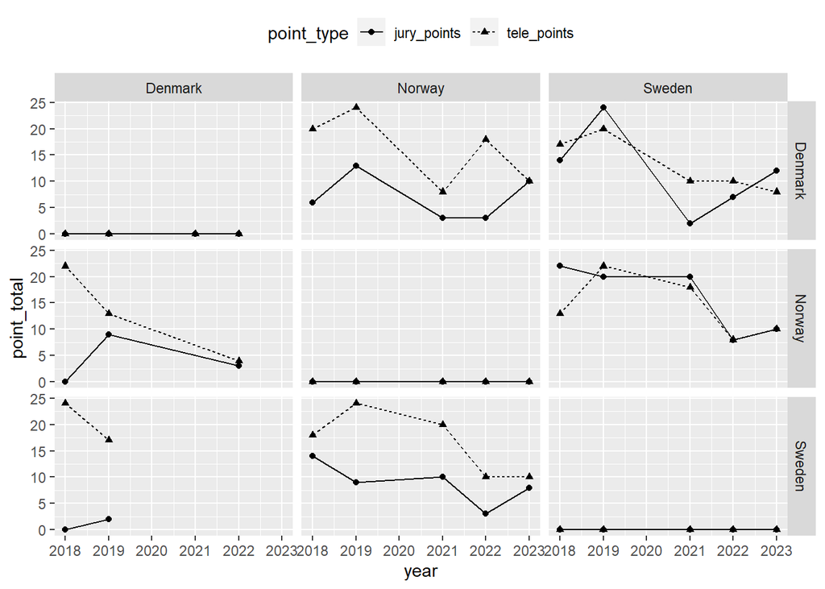

```r
votes_ready |>
    ggplot(aes(x = year,
             y = value,
             shape = name,
             linetype = name)) +
  geom_line() +
  geom_point() +
  facet_grid(from_country ~ to_country) +
  theme(legend.position="top") +
  labs(y = "point_total", shape = "point_type", linetype = "point_type")
```

# Problem 2

## Part A. 30 points.

Attached to the homework on HuskyCT, there are four Rda files: tmax.Rda, tmin.Rda, prcp.Rda, and tmax_tmin_prcp.Rda. These files provide historical weather data for four cities: Philadelphia, PA; Pittsburgh, PA; Erie, PA; Cleveland, OH. tmax is the max daily temperature, tmin is the min daily temperature, and prcp is the daily precipitation.

tmax.Rda, tmin.Rda, prcp.Rda are untidy representations of pieces of the weather data—one for tmax, one for tmin, and one for prcp. tmax_tmin_prcp.Rda is a tidy version of the three datasets brought together.

Your task is to use tmax.Rda, tmin.Rda, and prcp.Rda to exactly replicate the contents of tmax_tmin_prcp.Rda. This should be accomplished through a series of tidyverse verbs.

Please provide all the code to go from tmax.Rda, tmin.Rda, and prcp.Rda to a single dataframe matching tmax_tmin_prcp.

```r
# INSERT DATA LOADING CODE HERE
load("C:/Users/kruss/Downloads/tmax.Rda")
load("C:/Users/kruss/Downloads/tmin.Rda")
load("C:/Users/kruss/Downloads/prcp.Rda")
load("C:/Users/kruss/Downloads/tmax_tmin_prcp.Rda")
```

```r
# INSERT tmax manipulation CODE HERE
tmax_tidy <- tmax |>
  pivot_longer(
    cols = "pit,pa,01,01":"cle,oh,29,02",
    names_to = c("City", "State", "Day", "Month"),
    names_pattern = "(.*),(.*),(.*),(.*)"
  )
```

```r
tmax_tidy <- tmax_tidy |>
  mutate(State = toupper(State),
         City = ifelse(City == "pit", "Pittsburgh", (ifelse(City == "cle", "Cleveland", ifelse(City == "phi", "Philadelphia", "Erie"))))) |>
  mutate(Day = parse_number(Day)) |>
  mutate(tmax = value)
```

```r
tmax_tidy <- subset(tmax_tidy, select = -c(value))
```

```r
tmin_tidy <- tmin |>
  pivot_longer(
    cols = "pit_pa_01":"cle_oh_31",
    names_to = c("City", "State", "Day"),
    names_pattern = "(.*)_(.*)_(.*)"
  )
```

```r
tmin_tidy <- tmin_tidy |>
  mutate(State = toupper(State),
         City = ifelse(City == "pit", "Pittsburgh", (ifelse(City == "cle", "Cleveland", ifelse(City == "phi", "Philadelphia", "Erie"))))) |>
  mutate(Day = parse_number(Day)) |>
  mutate(tmin = value,
         Month = month)
```

```r
tmin_tidy <- subset(tmin_tidy, select = -c(value, month))
```

```r
prcp_tidy <- prcp |>
  pivot_longer(
    cols = "date01__01":"date29__02",
    names_to = c("Day", "Month"),
    names_pattern = "date(.*)__(.*)"
  )
```

```r
prcp_tidy <- prcp_tidy |>
  mutate(Day = parse_number(Day),
         prcp = value,
         State = state,
         City = city)
```

```r
prcp_tidy <- subset(prcp_tidy, select = -c(value, city, state))
```

```r
# INSERT joining and cleaning CODE HERE
temp <- tmax_tidy |>
  left_join(tmin_tidy)
final <- temp |>
  left_join(prcp_tidy)
# INSERT CODE that verifies your success HERE
# HINT: consider using names() to verify columns coincide
# HINT: consider using anti_join() to verify all rows are included.

final |>
  anti_join(tmax_tmin_prcp) |>
  count()
```

```
## # A tibble: 1 × 1
##       n
##   <int>
## 1     0
```

```r
tmax_tmin_prcp |>
  anti_join(final) |>
  count()
```

```
## # A tibble: 1 × 1
##       n
##   <int>
## 1     0
```

## Part B

### Question (i). 6 points.

Consider the data in tmax_tmin_prcp.Rda from 1971 to 2017. Is there any pattern to which days are missing temperatures? What do you think is causing this?

```r
tmax_tmin_prcp |>
  filter(is.na(tmax),
         year >= 1971,
         year <= 2017)
```

```
## # A tibble: 140 × 8
##      Day Month  year City         State  tmax  tmin  prcp
##    <dbl> <chr> <dbl> <chr>        <chr> <dbl> <dbl> <dbl>
##  1    29 02     1971 Pittsburgh   PA       NA    NA    NA
##  2    29 02     1971 Philadelphia PA       NA    NA    NA
##  3    29 02     1971 Erie         PA       NA    NA    NA
##  4    29 02     1971 Cleveland    OH       NA    NA    NA
##  5    29 02     1973 Pittsburgh   PA       NA    NA    NA
##  6    29 02     1973 Philadelphia PA       NA    NA    NA
##  7    29 02     1973 Erie         PA       NA    NA    NA
##  8    29 02     1973 Cleveland    OH       NA    NA    NA
##  9    29 02     1974 Pittsburgh   PA       NA    NA    NA
## 10    29 02     1974 Philadelphia PA       NA    NA    NA
## # ℹ 130 more rows
```

EXPLANATION GOES HERE. It certainly seems as though the leap days (February 29th) are the ones that are not being tracked. This is because those days do not exist most years. For instance, all cities are NA for February 29th, 2017. There was no 2/29/2017.

### BONUS Question (ii). 10 Points.

```r
avg_temp <- tmax_tmin_prcp |>
  filter(is.na(tmin) == FALSE,
         is.na(tmax) == FALSE) |>
  group_by(year, City, State) |>
  summarise(tmin = mean(tmin),
            tmax = mean(tmax)) |>
  pivot_longer(cols = c(tmin, tmax))
```

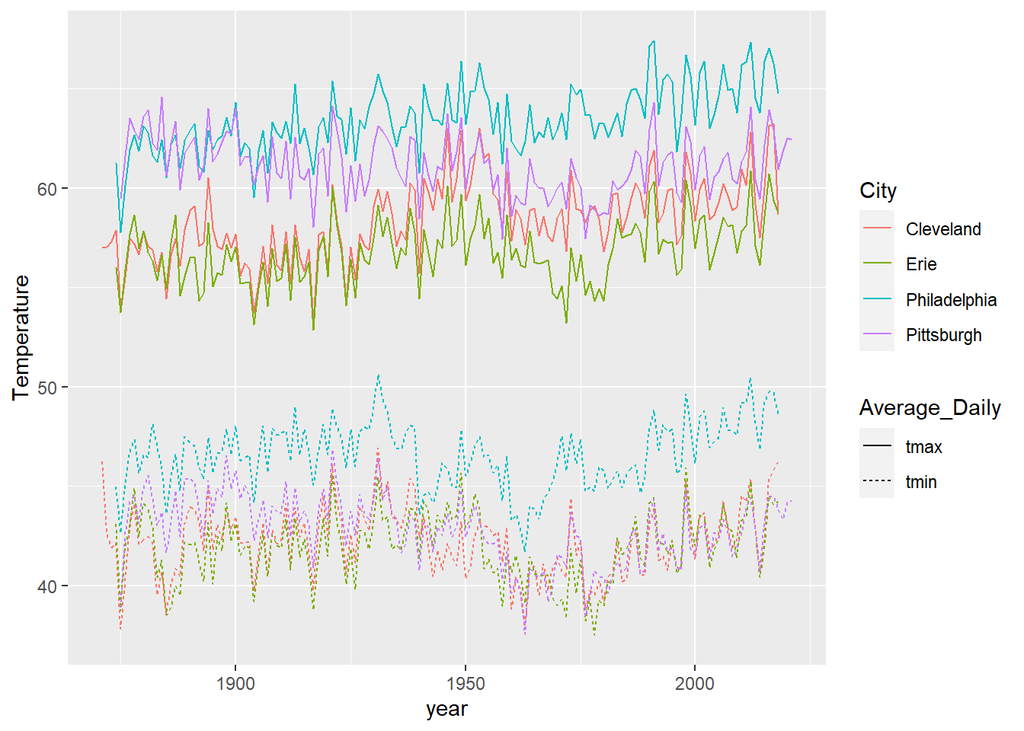

```r
avg_temp |>
    ggplot(aes(x = year, y = value, color = City, linetype = name)) +
  geom_line() +
  labs(y = "Temperature", linetype = "Average_Daily")
```